# **TAREA 5 - Grupo 5 (Japan)**

Integrantes:

- Palacios Ninahuanca, Ninoska
- Cerda Rioja, Lorena
- Lliuya Saldaña, Brayan

```python
#instalación de fiona
!pip install fiona
!pip install mapclassify
```

[output not shown]

```python
linkWorldMap="https://github.com/CienciaDeDatosEspacial/intro_geodataframe/raw/main/maps/worldMaps.gpkg"

import geopandas as gpd
from  fiona import listlayers   # FIONA PERMITE LEER LAYERS DE GPKD
listlayers(linkWorldMap)
```

```
['indicators', 'countries', 'rivers', 'cities']
```

```python
# Se exportan las capas nuestro interés
countries=gpd.read_file(linkWorldMap,layer='countries')
cities=gpd.read_file(linkWorldMap,layer='cities')
indicators=gpd.read_file(linkWorldMap,layer='indicators')
```

```python
# Se visualiza las 5 primeras filas
countries.head()
```

|  | COUNTRY | geometry |
| --- | --- | --- |
| 0 | Aruba (Netherlands) | MULTIPOLYGON (((-69.88223 12.41111, -69.94695 ... |
| 1 | Antigua and Barbuda | MULTIPOLYGON (((-61.73889 17.54055, -61.75195 ... |
| 2 | Afghanistan | MULTIPOLYGON (((61.27656 35.60725, 61.29638 35... |
| 3 | Algeria | MULTIPOLYGON (((-5.15213 30.18047, -5.13917 30... |
| 4 | Azerbaijan | MULTIPOLYGON (((46.54037 38.87559, 46.49554 38... |

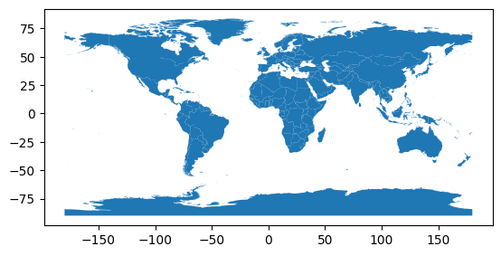

```python
# Se selecciona el subconjunto de countries y se plotea
countries.cx[:1000,:1000].plot()
```

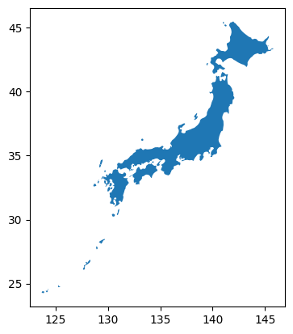

```python
# Se selecciona el país Japon
Japan=countries[countries.COUNTRY=='Japan']
Japan.plot()
```

```python
citiesJapan_clip = gpd.clip(gdf=cities,       #Aquí llama directamente del gdpk
                          mask=Japan)
citiesJapan_clip.crs.axis_info                #Llama los rios
```

```
[Axis(name=Geodetic latitude, abbrev=Lat, direction=north, unit_auth_code=EPSG, unit_code=9122, unit_name=degree),
 Axis(name=Geodetic longitude, abbrev=Lon, direction=east, unit_auth_code=EPSG, unit_code=9122, unit_name=degree)]
```

```python
# SE IMPORTAN LOS ARCHIVOS GPKG PASADOS DE LA TAREA 4

japan=Japan.to_crs(6684)
centroide=japan.centroid
cities_japan=citiesJapan_clip.to_crs(6684)
```

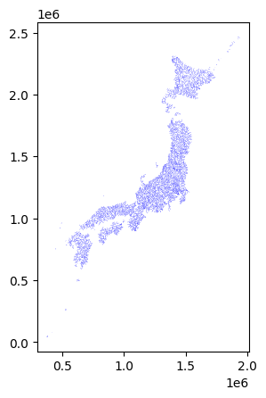

```python
# Se importa la capa de rios
rivers = gpd.read_file("https://github.com/brayan-lliuya-2024/TAREA_4-Grupo5/raw/refs/heads/main/maps/MapasJapon.gpkg", layer="rivers_jp")
rivers.plot(edgecolor='blue', linewidth=0.15)
```

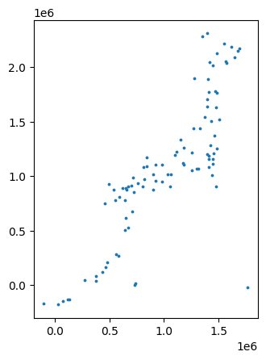

```python
# Se importan los aeropuertos principales de Japon
airports=gpd.read_file("https://github.com/brayan-lliuya-2024/TAREA_4-Grupo5/raw/refs/heads/main/maps/mapsjapan_ej2.gpkg",layer="airports")
airports_medium=airports[airports.kind=='medium_airport']
airports_medium.plot(markersize=3)
```

# EJERCICIO 1

**Realizar dos mapas:**

**1. Dibujar tu país como fondo. Usar cx para dibujar las ciudades (u otros puntos, por ejemplo, aeropuertos) debajo del centroide.**

**2. Dibujar tu país como fondo. Seleccionar con cx todas las primeras divisiones administrativas sobre el centroide. Luego, usar clip para mostrar los ríos que cruzan esas divisiones.**

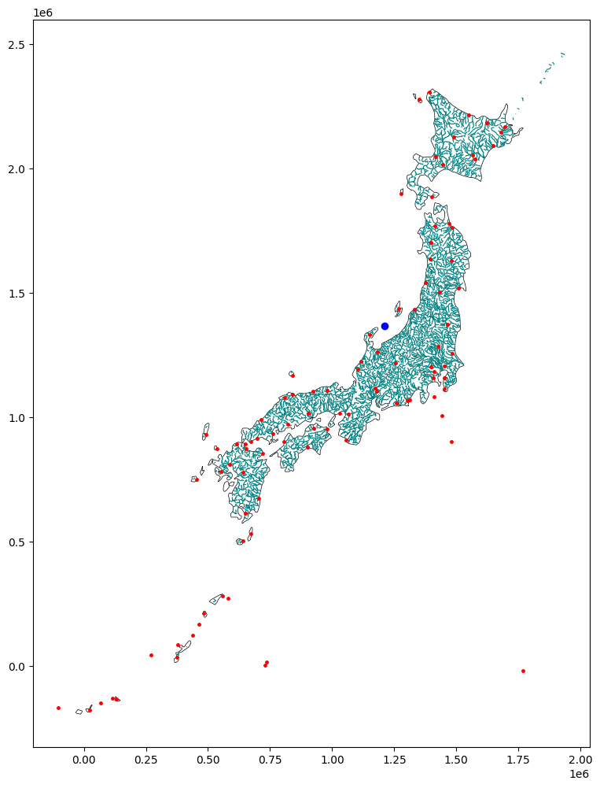

```python
# MAPA COMPLETO DE JAPON
base=japan.plot(facecolor="white",                            #Estableciendo la variable base a Japon
                      edgecolor='black',
                      linewidth=0.5,
                      figsize=(12,12))
rivers.plot(edgecolor='teal', linewidth=0.8,                  #Ploteando primera capa (rios)
            ax=base,zorder=1)
airports_medium.plot(marker='.', color='red',markersize=25,   #Ploteando segunda capa (aeropuertos principales)
            ax=base,zorder=2)

japan.centroid.plot(color='blue',ax=base)                     #Ploteando el centroide
```

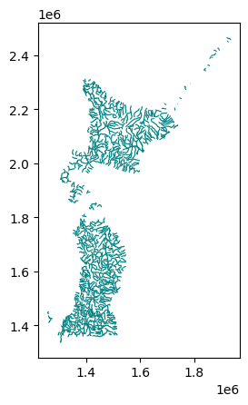

```python
# SE ESTABLECE EL CENTROIDE COMO EL PUNTO DE SEPARACIÓN
centroidX, centroidY = japan.centroid.x.values[0], japan.centroid.y.values[0]

# Corte de rios al norte del centroide
North_rivers = rivers.cx[:, centroidY:]
North_rivers.plot(edgecolor='teal', linewidth=0.8)
```

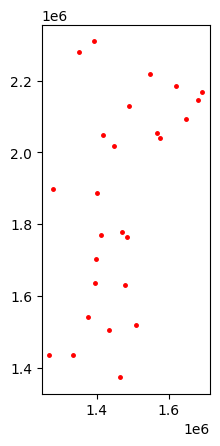

```python
# Corte de aeropuertos principales al norte del centroide
North_airports = airports_medium.cx[:, centroidY:]
North_airports.plot(marker='.', color='red',markersize=25)
```

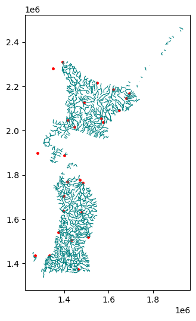

```python
# Ploteo de rios y aeropuertos al norte del centroide
baseE1=North_rivers.plot(edgecolor='teal', linewidth=0.8,figsize=(6,6))
North_airports.plot(marker='.', color='red',markersize=25,ax=baseE1)
```

# EJERCICIO 2

**1. Crear un subconjunto de polígonos con los datos de su país a nivel municipal (o similar). Utilizar la función UNION unaria con esos polígonos y crear un geoDF con el resultado.**

**2. Disuelva sus municipios por otro nivel administrativo de nivel superior. Dibujar el resultado.**

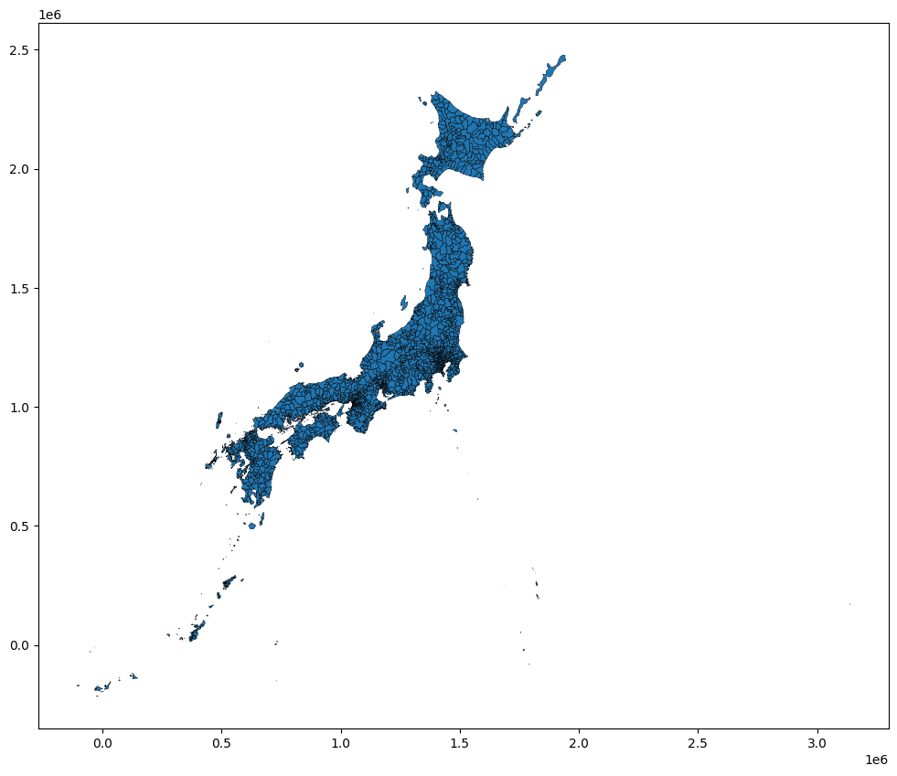

```python
# Se importa el shape "Municipios"
japan_adm2=gpd.read_file("https://github.com/brayan-lliuya-2024/TAREA_4-Grupo5/raw/refs/heads/main/maps/JaponAdm.gpkg",layer="Municipios")
japan_adm2.plot(edgecolor='black',linewidth=0.3,figsize=(12,12))
```

```python
# Se muestra la data de "japan_adm2" (municipios)
japan_adm2
```

|  | ADM0_EN | ADM0_JA | ADM0_PCODE | ADM1_EN | ADM1_JA | ADM1_PCODE | ADM2_JA | ADM2_EN | ADM2_PCODE | geometry |
| --- | --- | --- | --- | --- | --- | --- | --- | --- | --- | --- |
| 0 | Japan | 日本 | JP | Hokkaido | 北海道 | JP01 | えりも町 | Erimo Town | JP01001 | MULTIPOLYGON (((1588305.003 1978082.704, 15887... |
| 1 | Japan | 日本 | JP | Hokkaido | 北海道 | JP01 | せたな町 | Setana Town | JP01002 | MULTIPOLYGON (((1306716.907 1967507.577, 13071... |
| 2 | Japan | 日本 | JP | Hokkaido | 北海道 | JP01 | ニセコ町 | Niseko | JP01003 | MULTIPOLYGON (((1361334.222 2008683.526, 13618... |
| 3 | Japan | 日本 | JP | Hokkaido | 北海道 | JP01 | むかわ町 | Mukawa | JP01004 | MULTIPOLYGON (((1492410.768 2048940.161, 14925... |
| 4 | Japan | 日本 | JP | Hokkaido | 北海道 | JP01 | 七飯町 | Nanae | JP01005 | MULTIPOLYGON (((1384482.58 1917496.548, 138505... |
| ... | ... | ... | ... | ... | ... | ... | ... | ... | ... | ... |
| 1887 | Japan | 日本 | JP | Okinawa | 沖縄県 | JP47 | 西原町 | Nishihara-cho | JP47037 | MULTIPOLYGON (((376638.885 33578.667, 376362.3... |
| 1888 | Japan | 日本 | JP | Okinawa | 沖縄県 | JP47 | 読谷村 | Yomitan-son | JP47038 | MULTIPOLYGON (((373288.334 52170.966, 373726.7... |
| 1889 | Japan | 日本 | JP | Okinawa | 沖縄県 | JP47 | 豊見城市 | Tomigusuku City | JP47039 | MULTIPOLYGON (((368907.274 26785.223, 369485.7... |
| 1890 | Japan | 日本 | JP | Okinawa | 沖縄県 | JP47 | 那覇市 | Naha City | JP47040 | MULTIPOLYGON (((365233.384 32458.028, 366763.1... |
| 1891 | Japan | 日本 | JP | Okinawa | 沖縄県 | JP47 | 金武町 | Kin-cho | JP47041 | MULTIPOLYGON (((391711.067 61098.384, 392089.8... |

1892 rows × 10 columns

```python
# Se ve que tipo de objeto es "japan_adm2"
type(japan_adm2)
```

```
geopandas.geodataframe.GeoDataFrame
def __init__(data=None, *args, geometry=None, crs=None, **kwargs)
```

[output not shown]

```python
# Se comprueba su proyección en UTM
japan_adm2.crs.axis_info
```

```
[Axis(name=Northing, abbrev=X, direction=north, unit_auth_code=EPSG, unit_code=9001, unit_name=metre),
 Axis(name=Easting, abbrev=Y, direction=east, unit_auth_code=EPSG, unit_code=9001, unit_name=metre)]
```

```python
# Número de administraciones de tipo 2 (municipios)
len(japan_adm2.ADM2_EN)
```

```
1892
```

```python
# Número de administraciones de tipo 1 (regiones o provincias)
len(set(japan_adm2.ADM1_EN))
```

```
47
```

Usando UNARY UNION

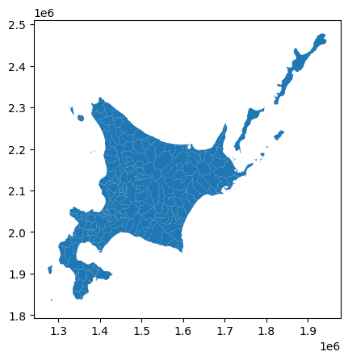

```python
# Se elige como región a Hokkaido (北海道), entonces se muestran los municipios (administración tipo 2) pertenecientes a esta región (administración tipo 1)
japan_adm2[japan_adm2.ADM1_JA=='北海道'].plot()       #Plotea los distritos de la provincia/prefectura de Hokkaido
```

```python
# Se usa UNION para unir los municipios pertenecientes a Hokkaido (北海道)
Hokkaido_union=japan_adm2[japan_adm2.ADM1_JA=='北海道'].union_all()
```

```python
Hokkaido_union
```

[figure not shown]

```python
# Se comprueba que no está en DataFrame
type(Hokkaido_union)      #SHAPELY -> union te da un shapely, geometría multipolígono, hay que convertirlo en shape para geopandas
```

```
shapely.geometry.multipolygon.MultiPolygon
```

```python
# Se convierte a DataFrame
Hokkaido_gdf=gpd.GeoDataFrame(index=[0],data={'ADM':'北海道'},
                 crs=japan_adm2.crs,
                 geometry=[Hokkaido_union])
```

```python
# Ahora está en DataFrame
type(Hokkaido_gdf)
```

```
geopandas.geodataframe.GeoDataFrame
def __init__(data=None, *args, geometry=None, crs=None, **kwargs)
```

[output not shown]

Usando **Dissolve** (alternativa a **union**)

```python
# Se elige como región a Okinawa (沖縄県), entonces se muestran los municipios (administración tipo 2) pertenecientes a esta región (administración tipo 1)
Okinawa_dissolve=japan_adm2[japan_adm2.ADM1_JA=='沖縄県'].dissolve()
```

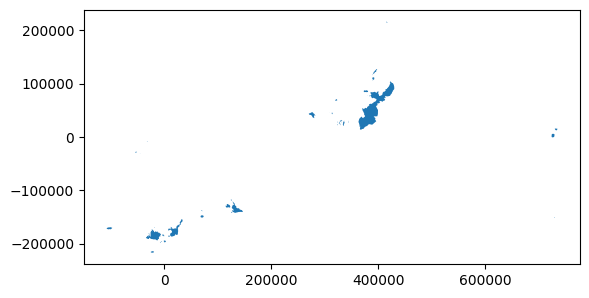

```python
# Se plotean los municipios correspondientes a Okinawa
Okinawa_dissolve.plot()
```

```python
# Al usar DISSOLVE, se muestra como DataFrame
type(Okinawa_dissolve)
```

```
geopandas.geodataframe.GeoDataFrame
def __init__(data=None, *args, geometry=None, crs=None, **kwargs)
```

[output not shown]

# EJERCICIO 3

**1. Seleccionar algunos puntos de sus mapas.**

**2. Crear la envoltura convexa para esos puntos.**

**3. Convertir la envoltura en un GDF. (si se hace con disolve, no es necesario hacer este paso)**

**4. Dibuje la envoltura sobre el país.**

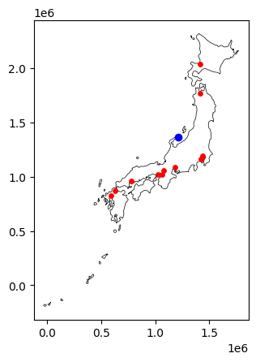

```python
# Se utilizara como puntos las ciudades de Japón
base3=japan.plot(facecolor="white",edgecolor='black',linewidth=0.5)     #Estableciendo la variable base3 a Japon
japan.centroid.plot(color='blue',ax=base3)
cities_japan.plot(color="red",markersize=15,ax=base3)
```

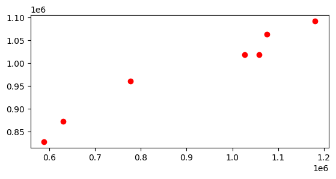

```python
# Se seleccionan las ciudades al Sur-Oeste (SW) desde el centroide
citiesSO_jp=cities_japan.cx[:centroidX,:centroidY]
citiesSO_jp.plot(color="red")
```

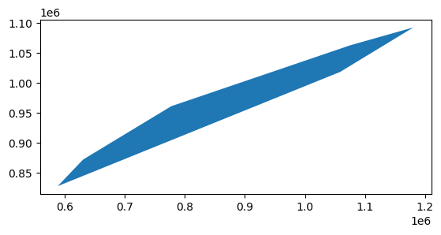

```python
# Creación del hull con dissolve
CitiesSO_hull=citiesSO_jp.dissolve().convex_hull
CitiesSO_hull.plot()
```

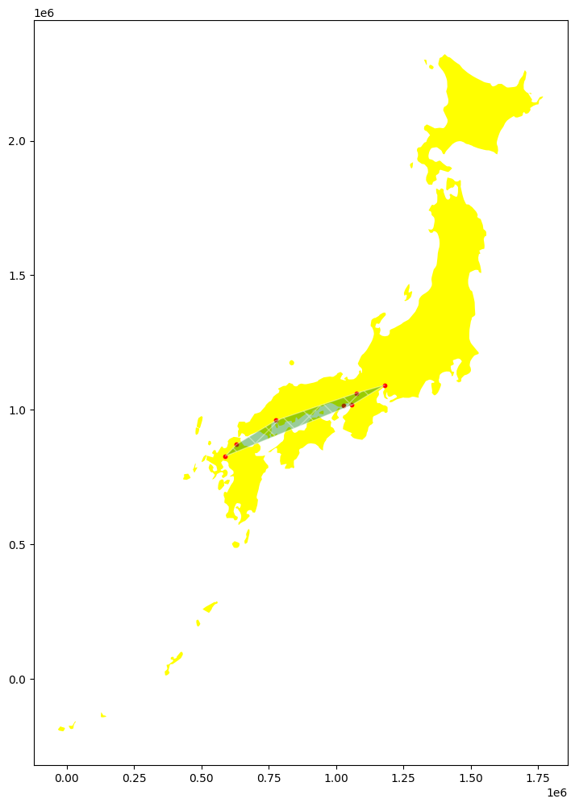

```python
# Mapa del hull con mapa base de Japón
base=japan.plot(facecolor="yellow",figsize=(12,12))
citiesSO_jp.plot(ax=base,markersize=10,color='red')
CitiesSO_hull.plot(ax=base,facecolor='green',
                       edgecolor='white',alpha=0.4,
                       hatch='X')
```

# EJERCICIO 4

**Aplique dos superposiciones espaciales a sus mapas.**

Superposición espacial: Necesidad de crear o encontrar algunas geometrias de las que se tiene. Se utiliza un enfoque de la teoria de conjuntos

```python
# Se realiza algunas operaciones geometricas
# Se separa las municipalidades por el centroide, según Norte, Sur, Este y Oeste

# North (N) / Norte
MunicipalitiesN_japan=japan_adm2.cx[:,centroidY:]  # japan_adm2 <> Municipalidades de japon
# Southt (S) / Sur
MunicipalitiesS_japan=japan_adm2.cx[:,:centroidY]
# West (W) / Oeste
MunicipalitiesW_japan=japan_adm2.cx[:centroidX,:]
# East (E) / Este
MunicipalitiesE_japan=japan_adm2.cx[centroidX:,:]
```

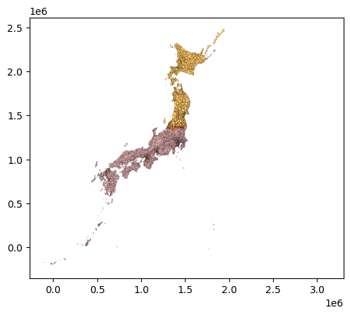

```python
# Se plotea:

# Norte y Sur se observa que tienen la misma franja en comun (donde pasa el centroide)
base=MunicipalitiesN_japan.plot(facecolor='orange', edgecolor='black',linewidth=0.2, alpha=0.6)
MunicipalitiesS_japan.plot(facecolor='brown', edgecolor='black',linewidth=0.2,ax=base, alpha=0.4)
```

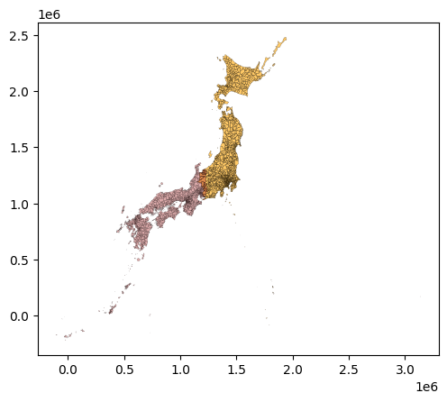

```python
# Se plotea:

# Este y Oste se observa igualmente que tienen una franja en comun (donde pasa el centroide)
base=MunicipalitiesE_japan.plot(facecolor='orange', edgecolor='black',linewidth=0.2, alpha=0.6)
MunicipalitiesW_japan.plot(facecolor='brown', edgecolor='black',linewidth=0.2,ax=base, alpha=0.4)
```

#### Intersección

Se mantiene lo comun entre los los GeoDF

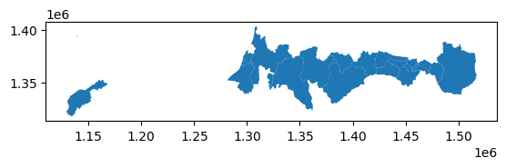

```python
# Se muestran las municipalidades en común ubicados en la franja Norte-Sur (NS)
MunicipalitiesNS_japan=MunicipalitiesN_japan.overlay(MunicipalitiesS_japan, how="intersection",keep_geom_type=True)
MunicipalitiesNS_japan.plot()
```

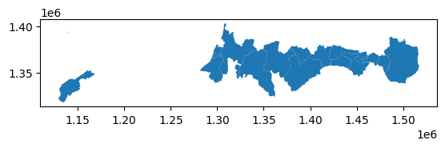

```python
# Nota: El procedimiento es similar al emplear un spatial join:
MunicipalitiesNS_japan.sjoin(MunicipalitiesS_japan, how="inner", predicate='contains').plot()   #Da el mismo resultado empleaando otro codigo
```

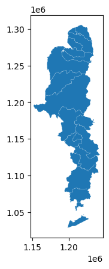

```python
# Manteniendo la superposición, se muestran las municipalidades en común ubicados en la franja Oeste-Este (WE)
MunicipalitiesWE_japan=MunicipalitiesW_japan.overlay(MunicipalitiesE_japan, how="intersection",keep_geom_type=True)
MunicipalitiesWE_japan.plot(edgecolor='white',linewidth=0.1)
```

#### Unión

Se realiza la unión de los dos GeoDF anteriores. Para ello, primero se observa la información de cada uno de ellos:

```python
# Se verifica las columnas presentes en NS
MunicipalitiesNS_japan.info()
```

```
<class 'geopandas.geodataframe.GeoDataFrame'>
RangeIndex: 18 entries, 0 to 17
Data columns (total 19 columns):
 #   Column        Non-Null Count  Dtype
---  ------        --------------  -----
 0   ADM0_EN_1     18 non-null     object
 1   ADM0_JA_1     18 non-null     object
 2   ADM0_PCODE_1  18 non-null     object
 3   ADM1_EN_1     18 non-null     object
 4   ADM1_JA_1     18 non-null     object
 5   ADM1_PCODE_1  18 non-null     object
 6   ADM2_JA_1     18 non-null     object
 7   ADM2_EN_1     18 non-null     object
 8   ADM2_PCODE_1  18 non-null     object
 9   ADM0_EN_2     18 non-null     object
 10  ADM0_JA_2     18 non-null     object
 11  ADM0_PCODE_2  18 non-null     object
 12  ADM1_EN_2     18 non-null     object
 13  ADM1_JA_2     18 non-null     object
 14  ADM1_PCODE_2  18 non-null     object
 15  ADM2_JA_2     18 non-null     object
 16  ADM2_EN_2     18 non-null     object
 17  ADM2_PCODE_2  18 non-null     object
 18  geometry      18 non-null     geometry
dtypes: geometry(1), object(18)
memory usage: 2.8+ KB
```

```python
# Se verifica las columnas presentes en WE
MunicipalitiesWE_japan.info()
```

```
<class 'geopandas.geodataframe.GeoDataFrame'>
RangeIndex: 20 entries, 0 to 19
Data columns (total 19 columns):
 #   Column        Non-Null Count  Dtype
---  ------        --------------  -----
 0   ADM0_EN_1     20 non-null     object
 1   ADM0_JA_1     20 non-null     object
 2   ADM0_PCODE_1  20 non-null     object
 3   ADM1_EN_1     20 non-null     object
 4   ADM1_JA_1     20 non-null     object
 5   ADM1_PCODE_1  20 non-null     object
 6   ADM2_JA_1     20 non-null     object
 7   ADM2_EN_1     20 non-null     object
 8   ADM2_PCODE_1  20 non-null     object
 9   ADM0_EN_2     20 non-null     object
 10  ADM0_JA_2     20 non-null     object
 11  ADM0_PCODE_2  20 non-null     object
 12  ADM1_EN_2     20 non-null     object
 13  ADM1_JA_2     20 non-null     object
 14  ADM1_PCODE_2  20 non-null     object
 15  ADM2_JA_2     20 non-null     object
 16  ADM2_EN_2     20 non-null     object
 17  ADM2_PCODE_2  20 non-null     object
 18  geometry      20 non-null     geometry
dtypes: geometry(1), object(18)
memory usage: 3.1+ KB
```

La superposición combina las geometrías, pero no los atributos. Por ende, se va a crear y mostrar un subconjunto:

```python
# Se unen las intersecciónes de NS y WE

keep=['ADM0_EN_1','geometry']  #Se mantienen estas columnas
MunicipalitiesNS_japan=MunicipalitiesNS_japan.loc[:,keep]
MunicipalitiesWE_japan=MunicipalitiesWE_japan.loc[:,keep]
```

```python
# Ahora, visualizamos los errores y/o celdas vacias que podrian existir
MunicipalitiesNS_japan.overlay(MunicipalitiesWE_japan,how="union",keep_geom_type=True)
```

|  | ADM0_EN_1_1 | ADM0_EN_1_2 | geometry |
| --- | --- | --- | --- |
| 0 | Japan | NaN | POLYGON ((1487925.662 1388243.879, 1488291.446... |
| 1 | Japan | NaN | POLYGON ((1423524.567 1377548.396, 1423150.764... |
| 2 | Japan | NaN | POLYGON ((1461129.538 1367269.933, 1461334.761... |
| 3 | Japan | NaN | POLYGON ((1385135.869 1369014.862, 1385360.734... |
| 4 | Japan | NaN | POLYGON ((1477407.975 1369096.718, 1477755.236... |
| 5 | Japan | NaN | POLYGON ((1363727.812 1384000.521, 1364207.945... |
| 6 | Japan | NaN | POLYGON ((1426275.273 1379452.843, 1426839.092... |
| 7 | Japan | NaN | POLYGON ((1381880.7 1378309.437, 1382261.438 1... |
| 8 | Japan | NaN | POLYGON ((1452037.208 1367040.611, 1452390.729... |
| 9 | Japan | NaN | POLYGON ((1435558.421 1372323.271, 1435915.929... |
| 10 | Japan | NaN | POLYGON ((1452557.566 1372165.133, 1452935.476... |
| 11 | Japan | NaN | POLYGON ((1469935.743 1370687.202, 1470415.782... |
| 12 | Japan | NaN | POLYGON ((1433360.039 1370268.457, 1433621.466... |
| 13 | Japan | NaN | MULTIPOLYGON (((1304610.892 1367174.292, 13041... |
| 14 | Japan | NaN | POLYGON ((1305420.671 1376567.678, 1305216.421... |
| 15 | Japan | NaN | MULTIPOLYGON (((1324807.604 1357432.447, 13251... |
| 16 | Japan | NaN | POLYGON ((1349923.038 1375007.43, 1350362.386 ... |
| 17 | Japan | NaN | MULTIPOLYGON (((1161758.332 1351439.369, 11622... |
| 18 | NaN | Japan | POLYGON ((1195222.621 1274014.974, 1195807.417... |
| 19 | NaN | Japan | POLYGON ((1209125.072 1301325.852, 1209078.348... |
| 20 | NaN | Japan | POLYGON ((1192379.97 1276061.175, 1192776.245 ... |
| 21 | NaN | Japan | POLYGON ((1231763.369 1282888.916, 1231705.583... |
| 22 | NaN | Japan | POLYGON ((1194326.317 1270119.514, 1194178.554... |
| 23 | NaN | Japan | POLYGON ((1199638.186 1288848.003, 1199970.832... |
| 24 | NaN | Japan | POLYGON ((1200264.891 1295417.749, 1201033.036... |
| 25 | NaN | Japan | POLYGON ((1220439.615 1181810.229, 1220853.835... |
| 26 | NaN | Japan | POLYGON ((1192587.106 1193668.406, 1192945.493... |
| 27 | NaN | Japan | POLYGON ((1223883.707 1161110.345, 1224421.456... |
| 28 | NaN | Japan | POLYGON ((1236987.059 1127380.327, 1237118.59 ... |
| 29 | NaN | Japan | POLYGON ((1212413.2 1157572.79, 1212774.084 11... |
| 30 | NaN | Japan | POLYGON ((1203467.108 1131227.114, 1203916.712... |
| 31 | NaN | Japan | POLYGON ((1210636.871 1157728.97, 1210163.925 ... |
| 32 | NaN | Japan | POLYGON ((1217425.72 1237884.396, 1216868.847 ... |
| 33 | NaN | Japan | POLYGON ((1222232.511 1238752.696, 1222275.751... |
| 34 | NaN | Japan | POLYGON ((1226113.266 1079078.549, 1226788.423... |
| 35 | NaN | Japan | MULTIPOLYGON (((1219494.864 1043855.234, 12198... |
| 36 | NaN | Japan | POLYGON ((1213375.567 1063653.39, 1213715.1 10... |
| 37 | NaN | Japan | POLYGON ((1237749.788 1115355.879, 1238108.565... |

```python
# Como se pudo observar anteriormente, las geometrias estan bien. No obstante, los atributos no

# Se importa pandas que servira para la intersección de ambos GeoDF (con Concat)
import pandas as pd

pd.concat([MunicipalitiesNS_japan,MunicipalitiesWE_japan],ignore_index=True)
```

|  | ADM0_EN_1 | geometry |
| --- | --- | --- |
| 0 | Japan | POLYGON ((1487925.662 1388243.879, 1488291.446... |
| 1 | Japan | POLYGON ((1423524.567 1377548.396, 1423150.764... |
| 2 | Japan | POLYGON ((1461129.538 1367269.933, 1461334.761... |
| 3 | Japan | POLYGON ((1385135.869 1369014.862, 1385360.734... |
| 4 | Japan | POLYGON ((1477407.975 1369096.718, 1477755.236... |
| 5 | Japan | POLYGON ((1363727.812 1384000.521, 1364207.945... |
| 6 | Japan | POLYGON ((1426275.273 1379452.843, 1426839.092... |
| 7 | Japan | POLYGON ((1381880.7 1378309.437, 1382261.438 1... |
| 8 | Japan | POLYGON ((1452037.208 1367040.611, 1452390.729... |
| 9 | Japan | POLYGON ((1435558.421 1372323.271, 1435915.929... |
| 10 | Japan | POLYGON ((1452557.566 1372165.133, 1452935.476... |
| 11 | Japan | POLYGON ((1469935.743 1370687.202, 1470415.782... |
| 12 | Japan | POLYGON ((1433360.039 1370268.457, 1433621.466... |
| 13 | Japan | MULTIPOLYGON (((1304610.892 1367174.292, 13041... |
| 14 | Japan | POLYGON ((1305420.671 1376567.678, 1305216.421... |
| 15 | Japan | MULTIPOLYGON (((1324807.604 1357432.447, 13251... |
| 16 | Japan | POLYGON ((1349923.038 1375007.43, 1350362.386 ... |
| 17 | Japan | MULTIPOLYGON (((1161758.332 1351439.369, 11622... |
| 18 | Japan | POLYGON ((1195222.621 1274014.974, 1195807.417... |
| 19 | Japan | POLYGON ((1209125.072 1301325.852, 1209078.348... |
| 20 | Japan | POLYGON ((1192379.97 1276061.175, 1192776.245 ... |
| 21 | Japan | POLYGON ((1231763.369 1282888.916, 1231705.583... |
| 22 | Japan | POLYGON ((1194326.317 1270119.514, 1194178.554... |
| 23 | Japan | POLYGON ((1199638.186 1288848.003, 1199970.832... |
| 24 | Japan | POLYGON ((1200264.891 1295417.749, 1201033.036... |
| 25 | Japan | POLYGON ((1220439.615 1181810.229, 1220853.835... |
| 26 | Japan | POLYGON ((1192587.106 1193668.406, 1192945.493... |
| 27 | Japan | POLYGON ((1223883.707 1161110.345, 1224421.456... |
| 28 | Japan | POLYGON ((1236987.059 1127380.327, 1237118.59 ... |
| 29 | Japan | POLYGON ((1212413.2 1157572.79, 1212774.084 11... |
| 30 | Japan | POLYGON ((1203467.108 1131227.114, 1203916.712... |
| 31 | Japan | POLYGON ((1210636.871 1157728.97, 1210163.925 ... |
| 32 | Japan | POLYGON ((1217425.72 1237884.396, 1216868.847 ... |
| 33 | Japan | POLYGON ((1222232.511 1238752.696, 1222275.751... |
| 34 | Japan | POLYGON ((1226113.266 1079078.549, 1226788.423... |
| 35 | Japan | MULTIPOLYGON (((1219494.864 1043855.234, 12198... |
| 36 | Japan | POLYGON ((1213375.567 1063653.39, 1213715.1 10... |
| 37 | Japan | POLYGON ((1237749.788 1115355.879, 1238108.565... |

Si se desea conservar los atributos, se deberá agregarlos. Pero si desea combinar los resultados finales, simplemente se debe realizar la superposición

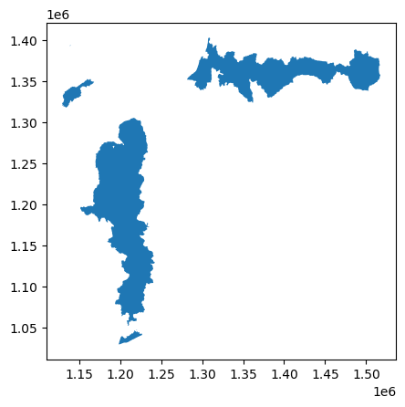

```python
# Se plotea la unión
MunicipalitiesNS_japan.dissolve().overlay(MunicipalitiesWE_japan.dissolve(), how="union",keep_geom_type=True).dissolve().plot()
```

Se crea un objeto para guardar el resultado anterior:

```python
MunicipalitiesMidJapan=MunicipalitiesNS_japan.dissolve().overlay(MunicipalitiesWE_japan.dissolve(), how="union",keep_geom_type=True).dissolve()
MunicipalitiesMidJapan
```

|  | geometry | ADM0_EN_1_1 | ADM0_EN_1_2 |
| --- | --- | --- | --- |
| 0 | MULTIPOLYGON (((1221266.258 1044130.591, 12214... | Japan | Japan |

```python
MunicipalitiesMidJapan=MunicipalitiesNS_japan.dissolve().overlay(MunicipalitiesWE_japan.dissolve(), how="union",keep_geom_type=True).dissolve()
MunicipalitiesMidJapan

# Se realiza una limpieza
MunicipalitiesMidJapan['zone']='middles'
MunicipalitiesMidJapan=MunicipalitiesMidJapan.loc[:,['ADM0_EN_1_1','zone','geometry']]
MunicipalitiesMidJapan
```

|  | ADM0_EN_1_1 | zone | geometry |
| --- | --- | --- | --- |
| 0 | Japan | middles | MULTIPOLYGON (((1221266.258 1044130.591, 12214... |

#### **Diferencia**

Aquí, se conserva lo que pertenece al GeoDF de la izquierda que no está en el GeoDF de la derecha:

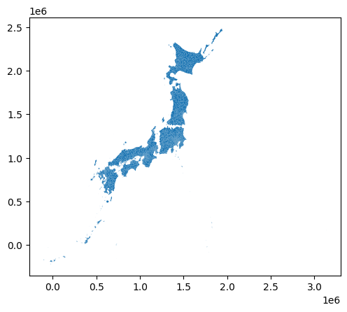

```python
# Con los municipios:
# Se plotea el resto de la unión
japan_adm2.overlay(MunicipalitiesMidJapan, how='difference').plot()
```

#### **Symmetric Difference (Diferencia simétrica)**

Esto es lo opuesto a *intersección*, conservas lo que no está en la intersección:

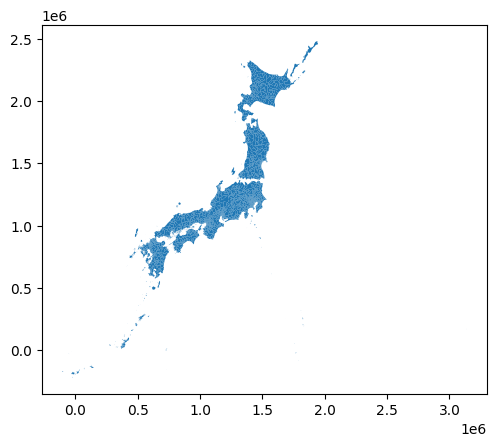

```python
# Se realiza una operación de diferencia simetrica entres los municipios del Norte (N) y Sur (S) de Japon. Se visualiza que no se superponen entre si
MunicipalitiesN_japan.overlay(MunicipalitiesS_japan, how="symmetric_difference",keep_geom_type=False).plot()
```

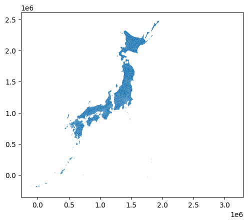

```python
# Se realiza una operación de diferencia simetrica entres los municipios del Oeste (W) y Este (E) de Japon. Se visualiza que no se superponen entre si
MunicipalitiesW_japan.overlay(MunicipalitiesE_japan, how="symmetric_difference",keep_geom_type=False).plot()
```

#### **Validación de la geometría**

Las geometrías se crean de tal manera que pueden aparecer algunos problemas, especialmente en polígonos (multi). Comprobemos si nuestros mapas recientes sobre estados y municipios son válidos:

```python
# Para filtrar y mostrar las geometrias no validas del GeoDF
japan_adm2[~japan_adm2.is_valid]

# Puesto que algunos poligonos tienen errores, se muestran los que no son válidos
```

|  | ADM0_EN | ADM0_JA | ADM0_PCODE | ADM1_EN | ADM1_JA | ADM1_PCODE | ADM2_JA | ADM2_EN | ADM2_PCODE | geometry |
| --- | --- | --- | --- | --- | --- | --- | --- | --- | --- | --- |
| 22 | Japan | 日本 | JP | Hokkaido | 北海道 | JP01 | 伊達市 | Date City | JP01023 | MULTIPOLYGON (((1380292.169 1970866.637, 13808... |
| 45 | Japan | 日本 | JP | Hokkaido | 北海道 | JP01 | 厚岸町 | Akkeshi-cho | JP01046 | MULTIPOLYGON (((1705056.042 2096583.351, 17046... |
| 88 | Japan | 日本 | JP | Hokkaido | 北海道 | JP01 | 新十津川 | Shintotsukawa-cho | JP01089 | MULTIPOLYGON (((1446781.927 2095419.058, 14471... |
| 123 | Japan | 日本 | JP | Hokkaido | 北海道 | JP01 | 清水町 | Shimizu-cho | JP01124 | MULTIPOLYGON (((1549402.46 2054751.746, 154908... |
| 160 | Japan | 日本 | JP | Hokkaido | 北海道 | JP01 | 苫小牧市 | Tomakomai City | JP01161 | MULTIPOLYGON (((1453642.43 2016769.885, 145352... |
| ... | ... | ... | ... | ... | ... | ... | ... | ... | ... | ... |
| 1789 | Japan | 日本 | JP | Miyazaki | 宮崎県 | JP45 | 川南町 | Kawaminami-cho | JP45008 | MULTIPOLYGON (((711904.673 716057.972, 711263.... |
| 1790 | Japan | 日本 | JP | Miyazaki | 宮崎県 | JP45 | 延岡市 | Nobeoka City | JP45009 | MULTIPOLYGON (((735049.58 766310.263, 735442.7... |
| 1794 | Japan | 日本 | JP | Miyazaki | 宮崎県 | JP45 | 日向市 | Hyuga City | JP45013 | MULTIPOLYGON (((720212.624 741504.1, 720466.25... |
| 1827 | Japan | 日本 | JP | Kagoshima | 鹿児島県 | JP46 | 奄美市 | Amami City | JP46020 | MULTIPOLYGON (((535450.008 266109.437, 534962.... |
| 1884 | Japan | 日本 | JP | Okinawa | 沖縄県 | JP47 | 竹富町 | Taketomi-cho | JP47034 | MULTIPOLYGON (((-20057.192 -216047.004, -20667... |

80 rows × 10 columns

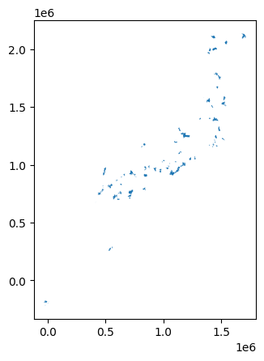

```python
# Se plotea los que son invalidos
japan_adm2[~japan_adm2.is_valid].plot()
```

Dado que es difícil de visualizar qué es lo que está mal es necesario el ver algo de información:

```python
# CUAL ES EL ERROR
# Se importa las funciones "explain_validity" y "make_valid" de "shapely.validation".Se utilizaran para para verificar la validación de las geometrias y corregir las no válidas
from shapely.validation import explain_validity, make_valid

explain_validity(japan_adm2[~japan_adm2.is_valid].geometry)
```

|  | geometry |
| --- | --- |
| 22 | Ring Self-intersection[1380292.16869885 197086... |
| 45 | Ring Self-intersection[1700650.85172969 210720... |
| 88 | Ring Self-intersection[1447910.04428046 210112... |
| 123 | Ring Self-intersection[1549402.46045458 205475... |
| 160 | Ring Self-intersection[1451545.12664932 200135... |
| ... | ... |
| 1789 | Ring Self-intersection[711904.67254311 716057.... |
| 1790 | Ring Self-intersection[729551.928291748 762860... |
| 1794 | Ring Self-intersection[720740.38709956 740435.... |
| 1827 | Ring Self-intersection[535450.008073925 266109... |
| 1884 | Ring Self-intersection[-23176.5945992681 -1752... |

80 rows × 1 columns

**dtype:** object

```python
# Ahora, se cuentan los errores
japan_adm2['validity']=[x.split('[')[0] for x in japan_adm2.geometry.apply(lambda x: explain_validity(x))]
japan_adm2['validity'].value_counts()
```

| validity | count |
| --- | --- |
| Valid Geometry | 1812 |
| Ring Self-intersection | 80 |

**dtype:** int64

```python
# Se deben resolver los errores y se visualizara, de manera que ya no haya errores para las lecturas

# Resolviendo el problema:
japan_adm2.drop(columns=['validity'],inplace=True)
japan_adm2_valid=japan_adm2.copy()
japan_adm2_valid['geometry'] = [make_valid(row)  if not row.is_valid else row for row in japan_adm2_valid['geometry'] ]

# Se va a visualizar si existe alguno que sea no válido
japan_adm2_valid[~japan_adm2_valid.is_valid]
```

|  | ADM0_EN | ADM0_JA | ADM0_PCODE | ADM1_EN | ADM1_JA | ADM1_PCODE | ADM2_JA | ADM2_EN | ADM2_PCODE | geometry |
| --- | --- | --- | --- | --- | --- | --- | --- | --- | --- | --- |

La *solution* que obtuvimos puede ayudar con algunas técnicas avanzadas, pero también puede ocasionarnos algunos problemas adicionales. Una ves que Geopandas resolvio el inconveniente, ha creado **collections**:

```python
# El 3er tipo es "geometry collection" (entre polígonos, líneas, etc), es util para el manejo de datos pero siguen siendo errores para la lectura de shapefiles
pd.Series([type(x) for x in japan_adm2_valid.geometry]).value_counts()
```

|  | count |
| --- | --- |
| <class 'shapely.geometry.multipolygon.MultiPolygon'> | 1853 |
| <class 'shapely.geometry.polygon.Polygon'> | 29 |
| <class 'shapely.geometry.collection.GeometryCollection'> | 10 |

**dtype:** int64

Sin embargo, la presencia de colecciones puede resultar problemática en los shapefiles.